# Projet

Liao Yonghan et Basile Jézéquel

## Donnée 1

### Description du problème

*Le quotidien régional Ouest France réalise une enquête auprès de 340 abonnés de Rennes et de sa région. Le but général de cette enquête était de mieux connaître ses lecteurs et de savoir ce qui était lu dans le journal.*

premièrement on lit les données:

```r
donnee1 = read.csv2("OuestFrance.csv",header = TRUE,encoding = "latin1")

head(donnee1[,1:9],5)
```

|  | X | Zone | Sexe | Situation_famille | Age | CSP | Nb_enfants | Instruction | Habitat |
| --- | --- | --- | --- | --- | --- | --- | --- | --- | --- |
| 1 | 1 | NR | Homme | Marié | 18-26 ans | Etudiant-scolaire | Sans enfants | Supérieur | Appart. locataire |
| 2 | 2 | NR | Femme | Marié | 39-55 ans | Comm_Arti | Sans enfants | Secondaire | Appart. locataire |
| 3 | 3 | Z. résidentielle | Femme | NR | NR | Cadre moyen | Sans enfants | Supérieur | Appart. locataire |
| 4 | 4 | NR | Homme | Célibataire | 18-26 ans | NR | Sans enfants | Supérieur | NR |
| 5 | 5 | Z. résidentielle | Femme | Célibataire | NR | Cadre moyen | Sans enfants | Supérieur | Appart. locataire |

remarque: La commande *head* nous permet de voir le contenu essentiel de données.

On souhaite effectuer un ACM pour analyser des données.

```r
summary(donnee1)
```

```
##        X              Zone               Sexe           Situation_famille
##  Min.   :  1.00   Length:340         Length:340         Length:340
##  1st Qu.: 85.75   Class :character   Class :character   Class :character
##  Median :170.50   Mode  :character   Mode  :character   Mode  :character
##  Mean   :170.50
##  3rd Qu.:255.25
##  Max.   :340.00
##      Age                CSP             Nb_enfants        Instruction
##  Length:340         Length:340         Length:340         Length:340
##  Class :character   Class :character   Class :character   Class :character
##  Mode  :character   Mode  :character   Mode  :character   Mode  :character
##
##
##
##    Habitat          Informations_locales Informations_politiques
##  Length:340         Length:340           Length:340
##  Class :character   Class :character     Class :character
##  Mode  :character   Mode  :character     Mode  :character
##
##
##
##     Sports           Lariflette         Télévision
##  Length:340         Length:340         Length:340
##  Class :character   Class :character   Class :character
##  Mode  :character   Mode  :character   Mode  :character
##
##
##
##  Cérémonies_officielles Informations_sociales    Décès
##  Length:340             Length:340            Length:340
##  Class :character       Class :character      Class :character
##  Mode  :character       Mode  :character      Mode  :character
##
##
##
##   Accidents         Petites_annonces   Première_page       Feuilleton
##  Length:340         Length:340         Length:340         Length:340
##  Class :character   Class :character   Class :character   Class :character
##  Mode  :character   Mode  :character   Mode  :character   Mode  :character
##
```

[output cut: 22 more lines]

```
##
##  Jeunesse_et_éducation Annonces_emplois   Faits_divers       Reportage_page_2
##  Length:340            Length:340         Length:340         Length:340
##  Class :character      Class :character   Class :character   Class :character
##  Mode  :character      Mode  :character   Mode  :character   Mode  :character
##
##
##
##  Courrier_des_consommateurs Nb_rubriques_lues_QT Nombre_rubriques_lues_QL
##  Length:340                 Min.   : 0.00        Length:340
##  Class :character           1st Qu.: 9.00        Class :character
##  Mode  :character           Median :12.00        Mode  :character
##                             Mean   :11.92
##                             3rd Qu.:15.00
##                             Max.   :26.00
```

On souaite de voir la fréquence des huit premiers variables signalétique des enquêtés.

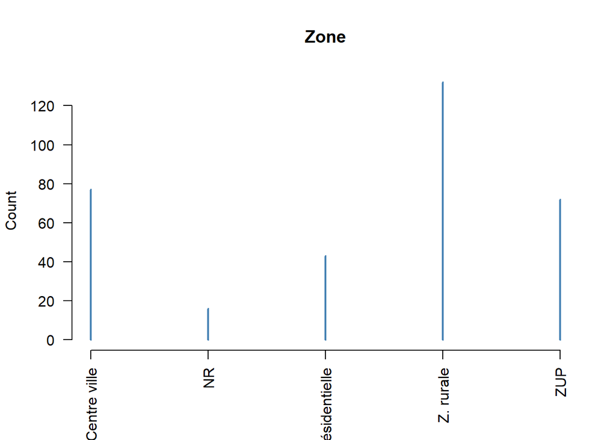

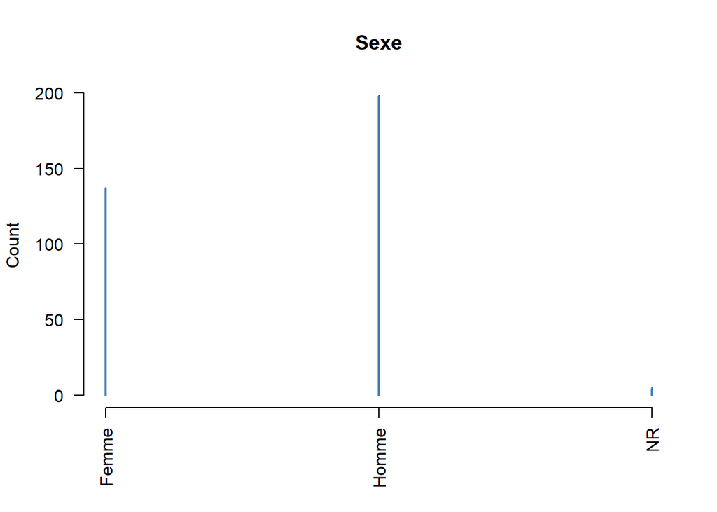

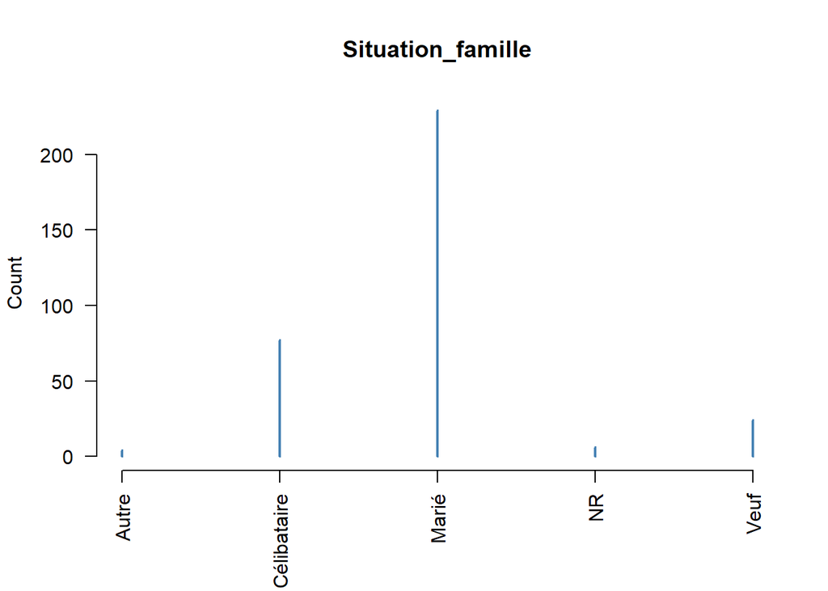

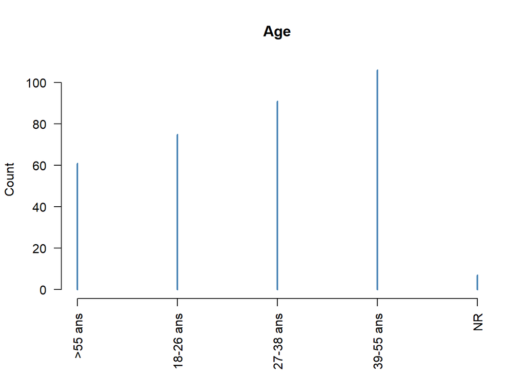

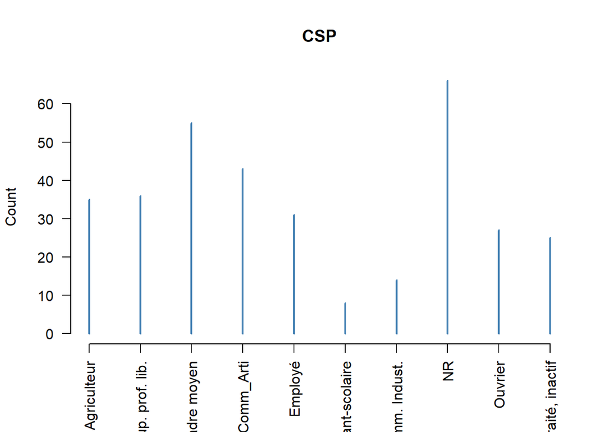

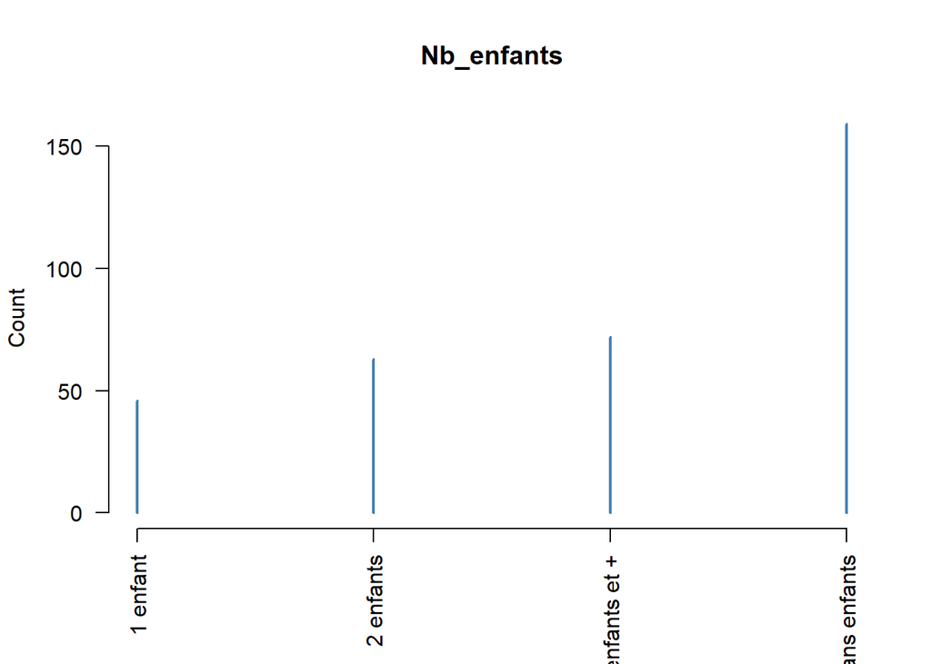

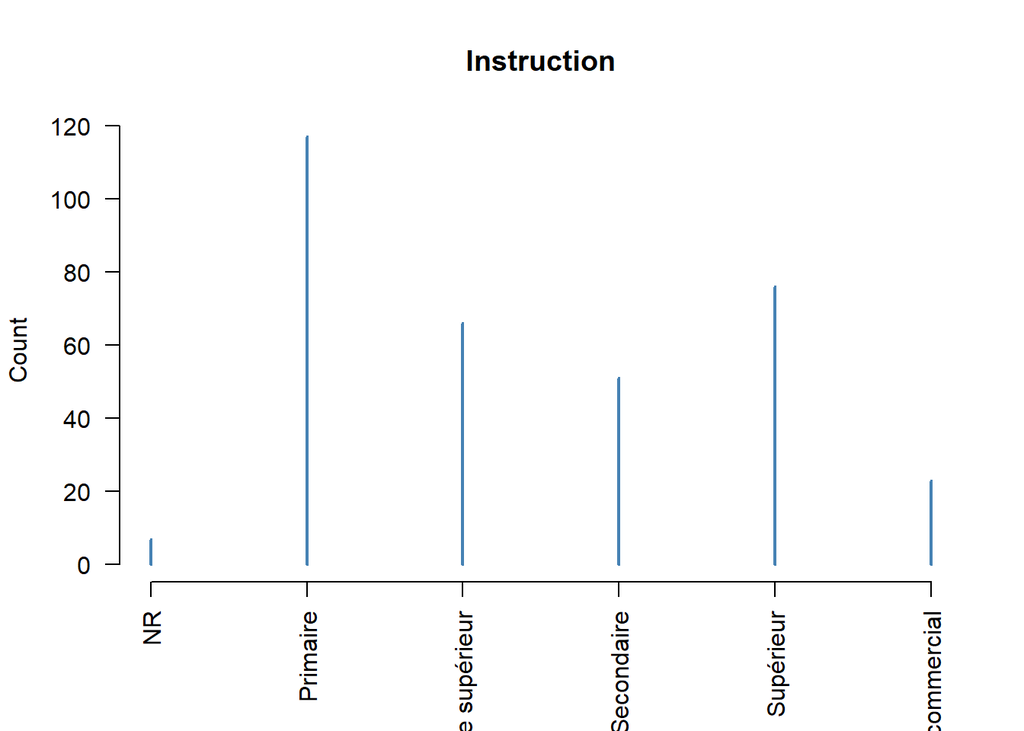

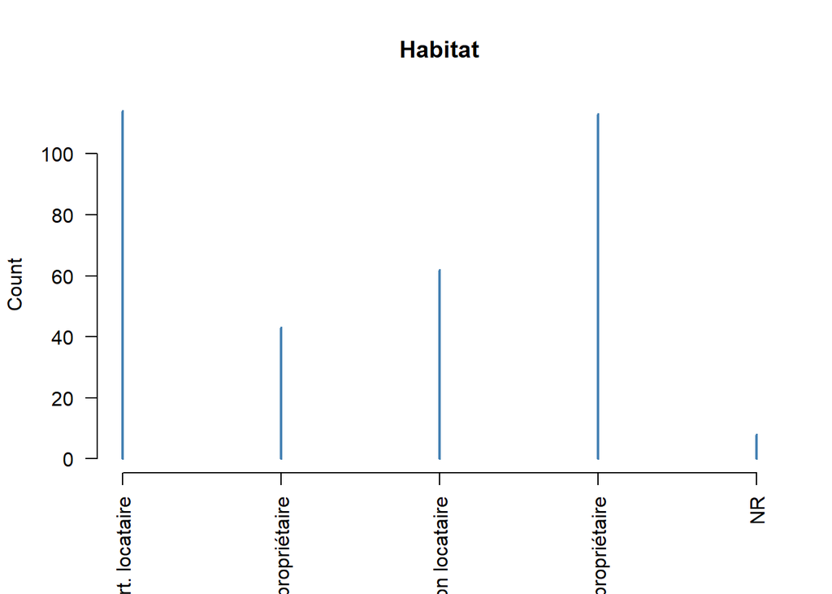

```r
for (i in 2:9) {
  plot(table(donnee1[,i]), main=colnames(donnee1)[i],
       ylab = "Count", col="steelblue", las = 2)
  }
```

D’après les tableaux de fréquence, pour les 8 premiers varaibles concernent la signalétique des enquêtés, on peut donc conclure:

- la plupart des abonnées viennent de **centre ville** et **Z.rurale**
- On a enquêté des hommes plus que les femmes
- Beaucoup d’entre eux sont déja mariés
- Le groupe d’âge moyen est la majorité des répondants à ce questionnaire
- Tous les groupes professionnels ont été enquetés.
- Beaucoup d’entre eux n’ont pas enfants
- Ils n’ont pas un niveau d’éducation élévé

Ensuite, On va installer les packages *FacotminR* et *factoextra* en aidant à analyser.

```r
library("FactoMineR")
library("factoextra")
```

On construit un variable de multi-dimension nommé *donnee1_mca*

```r
donnee1_mca<-MCA(donnee1,quanti.sup = c(1,36),graph = FALSE)
donnee1_liste<-donnee1[,-c(1:9)]
donnee1_liste_mca<-MCA(donnee1_liste,quanti.sup = 27,graph = FALSE)
```

On choisit du nombre d’axes à analyser

```r
#install.packages("rlang")
library(rlang)
```

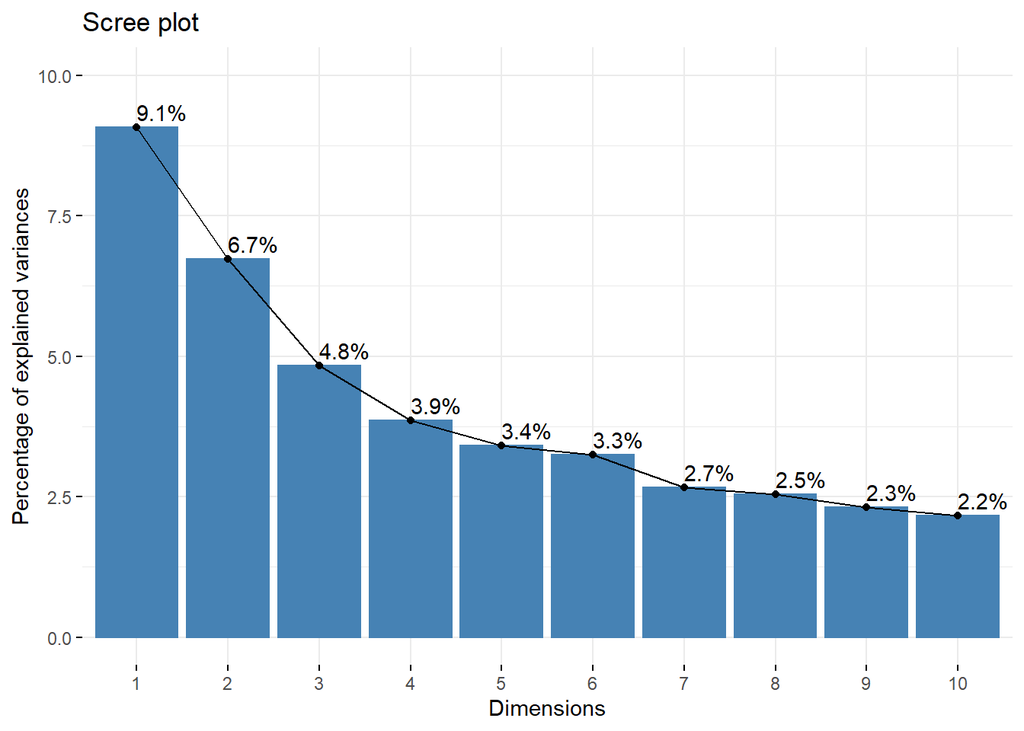

```r
fviz_screeplot(donnee1_mca, addlabels = TRUE, ylim = c(0,10))
```

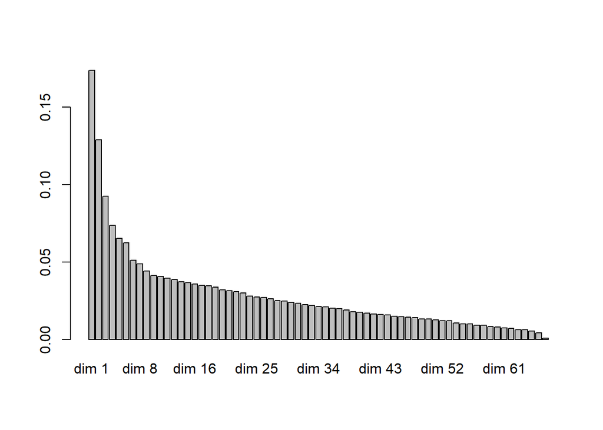

```r
#ou essayer de coder
barplot(donnee1_mca$eig[,1])
```

En regardant le graphe, nous conservons donc 3 axes.

Puis, nous allons afficher les rapports de corrélation entre les variables et les axes.

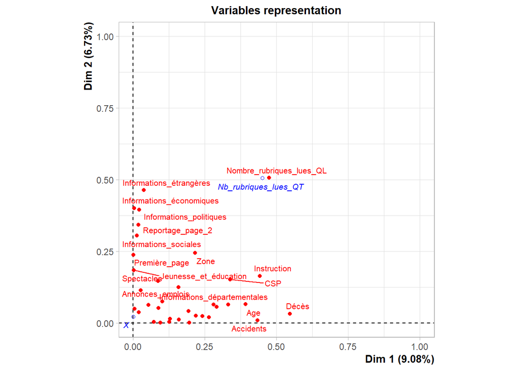

```r
# Représentation graphique
plot.MCA(donnee1_mca, choix="var", cex=0.7)
```

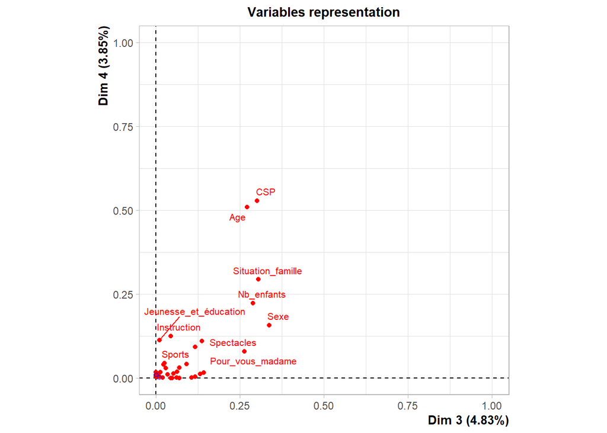

```r
plot(donnee1_mca, choix="var", cex=0.7, axes=3:4)
```

On a donc la liste des variables les plus liées à chacun des axes - Axe 1 : Décès,Nombre_rubriques_lues_QL et Accidents - Axe 2 : Nombre_rubriques_lues_QL, Informations_étrangères, Informations_économiques - Axe 3 : Sexe, Situation_famille, Nb_enfants

On peut vérifier notre interprétation en codant:

```r
# Description automatique des axes
dimdesc(donnee1_mca)[[1]]$quali
```

```
##                                      R2      p.value
## Décès                        0.54666709 5.032233e-60
## Nombre_rubriques_lues_QL     0.47387906 1.167958e-43
## Accidents                    0.43341829 1.313482e-43
## Instruction                  0.44250236 2.049420e-40
## Age                          0.39271383 3.491701e-35
## Situation_famille            0.33225130 2.376306e-28
## Courrier_des_consommateurs   0.29191260 3.682720e-27
## Courrier_des_lecteurs        0.28013252 6.108538e-26
## CSP                          0.33864229 2.885693e-25
## Au_jour_le_jour              0.26405342 2.629342e-24
## Informations_locales         0.24238161 3.699483e-22
## Cérémonies_officielles       0.21833743 7.645431e-20
## Faits_divers                 0.19603460 9.354441e-18
## Zone                         0.21603083 7.335835e-17
## Habitat                      0.19310330 8.223049e-15
## Pour_vous_madame             0.15912902 2.037235e-14
## Informations_départementales 0.15790264 2.615958e-14
## Télévision                   0.12909164 8.488440e-12
## Informations_agricoles       0.12592596 1.585976e-11
## Petites_annonces             0.10222685 1.610498e-09
## Feuilleton                   0.09508793 6.355763e-09
## Spectacles                   0.08683026 3.079636e-08
## Lariflette                   0.07177951 5.333544e-07
## Nb_enfants                   0.08810647 8.354739e-07
## Sexe                         0.05426814 8.258693e-05
## Informations_étrangères      0.03737319 3.365302e-04
## Annonces_emplois             0.02649445 2.609039e-03
## Informations_politiques      0.02192443 6.232416e-03
## Sports                       0.02009202 8.863484e-03
## Reportage_page_2             0.01805075 1.315755e-02
## Informations_sociales        0.01359804 3.158577e-02
```

```r
dimdesc(donnee1_mca)[[2]]$quali
```

```
##                                      R2      p.value
## Nombre_rubriques_lues_QL     0.50643281 3.205071e-48
## Informations_étrangères      0.46342857 1.287529e-47
## Informations_économiques     0.40080769 1.747819e-39
## Informations_politiques      0.39591112 6.957858e-39
## Reportage_page_2             0.34357073 9.364965e-33
## Informations_sociales        0.30475933 1.633651e-28
## Première_page                0.23746568 1.114777e-21
## Zone                         0.24534659 1.402648e-19
## Jeunesse_et_éducation        0.18468241 1.029701e-16
## Spectacles                   0.14685605 2.451073e-13
## Instruction                  0.16461500 1.034184e-11
## Informations_départementales 0.12463559 2.045075e-11
## Annonces_emplois             0.11485727 1.389913e-10
## CSP                          0.15215711 1.197836e-08
## Petites_annonces             0.07548342 2.650796e-07
## Courrier_des_lecteurs        0.06543580 1.760160e-06
## Courrier_des_consommateurs   0.05654486 9.325471e-06
## Sexe                         0.06343584 1.599833e-05
## Informations_maritimes       0.04944217 3.521120e-05
## Age                          0.06591928 1.318464e-04
## Situation_famille            0.06512176 1.504201e-04
## Sports                       0.03775860 3.130878e-04
## Nb_enfants                   0.05235192 4.206150e-04
## Décès                        0.03318145 7.388792e-04
## Cérémonies_officielles       0.02540585 3.207846e-03
## Informations_locales         0.02410938 4.105296e-03
## Habitat                      0.04165980 6.403918e-03
## Au_jour_le_jour              0.01987581 9.240869e-03
## Télévision                   0.01468769 2.543721e-02
## Pour_vous_madame             0.01209513 4.270594e-02
```

```r
dimdesc(donnee1_mca)[[3]]$quali
```

```
##                                      R2      p.value
## Sexe                         0.33672664 9.019761e-31
## Situation_famille            0.30540445 1.612156e-25
## Nb_enfants                   0.28828656 1.220101e-24
## Pour_vous_madame             0.26280483 3.509707e-24
## Age                          0.27143731 4.269172e-22
## CSP                          0.30022952 2.120478e-21
## Spectacles                   0.13661636 1.906004e-12
## Informations_agricoles       0.11664447 9.804921e-11
## Sports                       0.11627391 1.054111e-10
## Zone                         0.14211672 1.752894e-10
## Feuilleton                   0.10649471 7.059643e-10
## Habitat                      0.13206069 1.150690e-09
## Télévision                   0.07001635 7.435651e-07
## Annonces_emplois             0.06951745 8.168162e-07
## Informations_politiques      0.06237884 3.124846e-06
## Informations_économiques     0.06174125 3.521894e-06
## Nombre_rubriques_lues_QL     0.09172800 1.474895e-05
## Cérémonies_officielles       0.05253940 1.973194e-05
## Informations_locales         0.04818662 4.452593e-05
## Informations_départementales 0.04471552 8.519288e-05
## Petites_annonces             0.03458187 5.679991e-04
## Informations_sociales        0.02962978 1.442039e-03
## Lariflette                   0.02532821 3.255521e-03
## Au_jour_le_jour              0.02338081 4.717256e-03
## Informations_étrangères      0.01970903 9.543140e-03
## Instruction                  0.04410244 9.812162e-03
## Courrier_des_lecteurs        0.01355397 3.186469e-02
```

Visualiser uniquement les catégories de variables

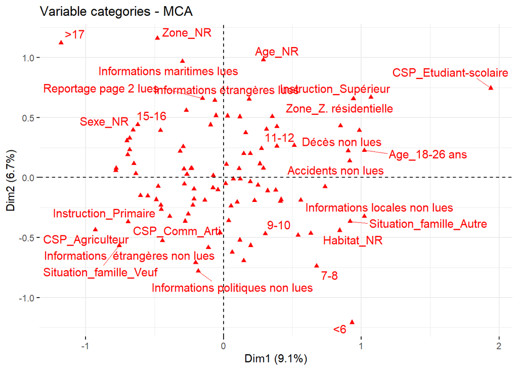

```r
fviz_mca_var(donnee1_mca,
             repel = TRUE, # Avoid text overlapping (slow)
             ggtheme = theme_minimal())
```

On peut conclure suivant:

- Les catégories de variables ayant un profil similaire sont regroupées.
- Les catégories de variables négativement corrélées sont positionnées sur les côtés opposés de l’origine du tracé (quadrants opposés).
- La distance entre les points de catégorie et l’origine mesure la qualité de la catégorie de variable sur la carte factorielle. Les points de catégorie éloignés de l’origine sont bien représentés sur la carte des facteurs

nous pouvons dessiner un diagramme à barres de la contribution des catégories de variables. Le code R ci-dessous montre les 15 principales catégories de variables contribuant aux dimensions:

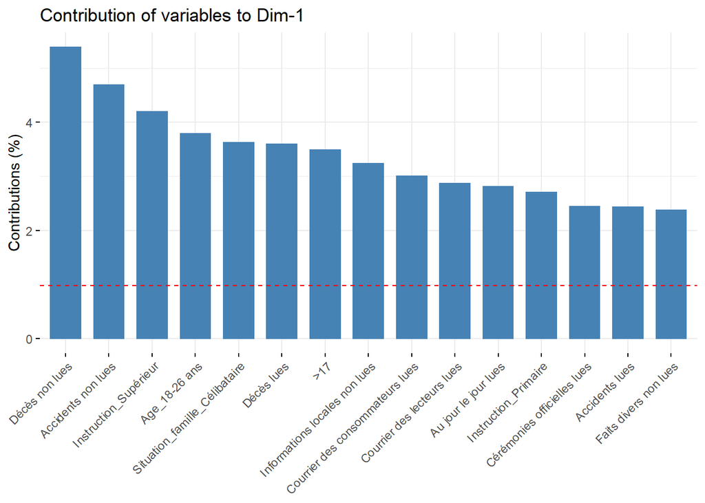

```r
fviz_contrib(donnee1_mca, choice = "var", axes = 1, top = 15)
```

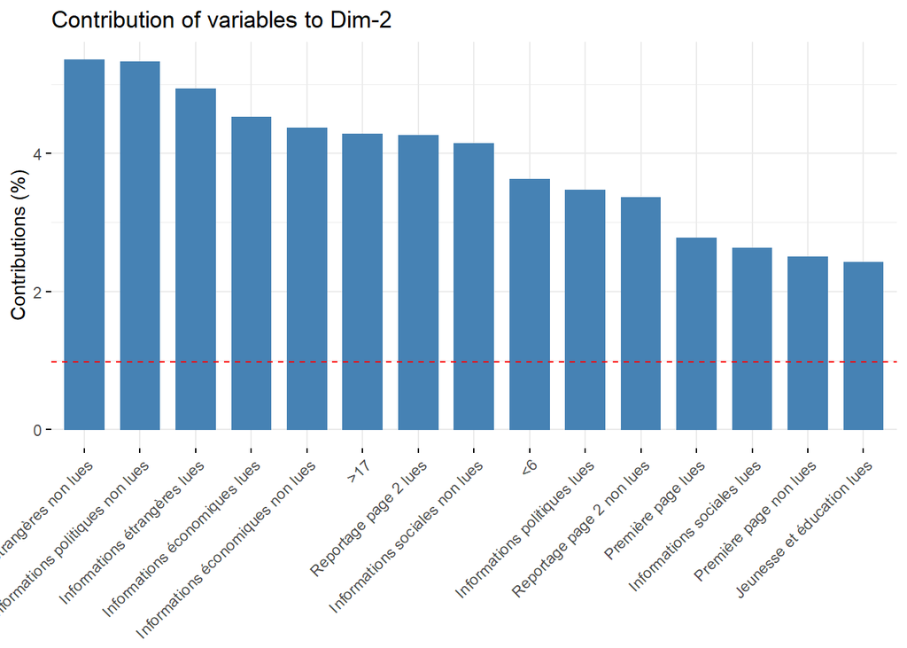

```r
# Contributions of rows to dimension 2
fviz_contrib(donnee1_mca, choice = "var", axes = 2, top = 15)
```

Puis, Les contributions totales aux dimensions 1 et 2 sont obtenues comme suit

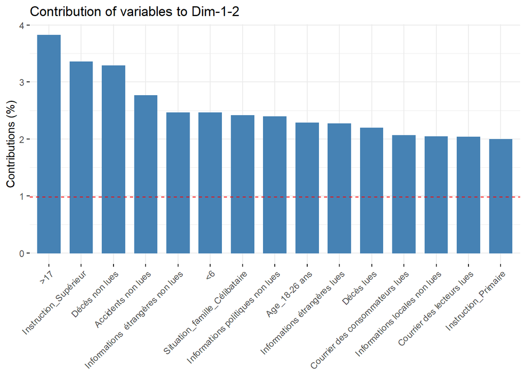

```r
fviz_contrib(donnee1_mca, choice = "var", axes = 1:2, top = 15)
```

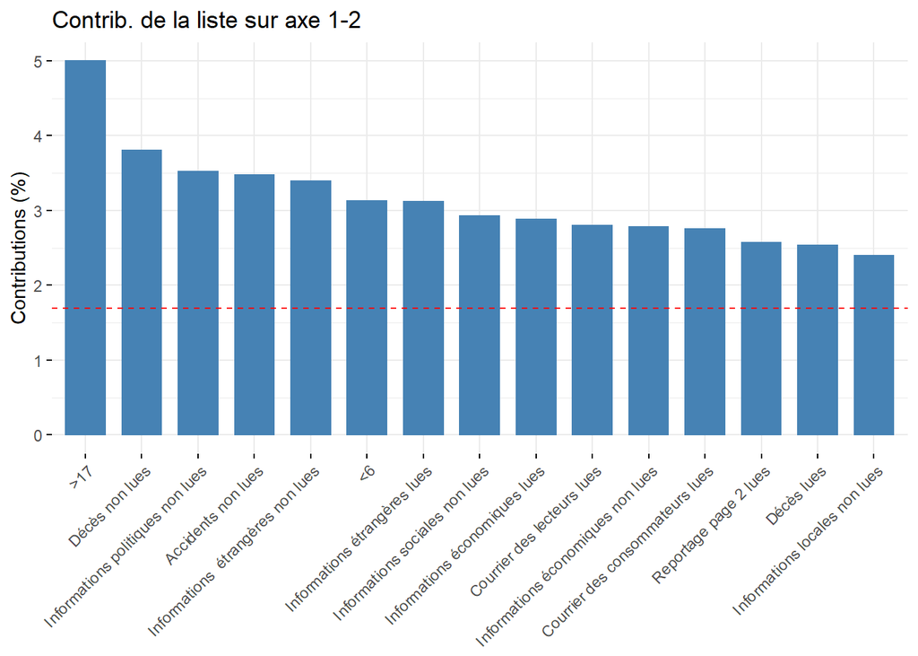

```r
fviz_contrib(donnee1_liste_mca, choice = "var", axes = 1:2, top = 15, title ="Contrib. de la liste sur axe 1-2")
```

D’après le graphe, on peut dire donc les modalités ayant le plus contribué aux axes 1,2 sont : - Nombres de rubrique >17 - Décès non lues - Informations politiques non lues.

Ensuite, on va vérifier les résultats en projetant les modalités des variables actives sur le(s) plan(s) factoriel(s) en faisant apparaître les labels

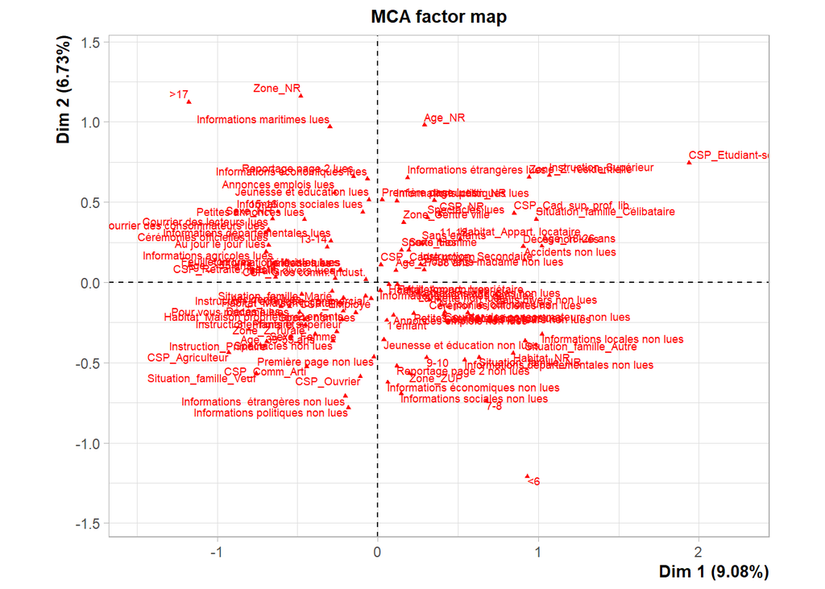

```r
plot(donnee1_mca,invisible=c("ind","quali.sup"), cex=0.6)
```

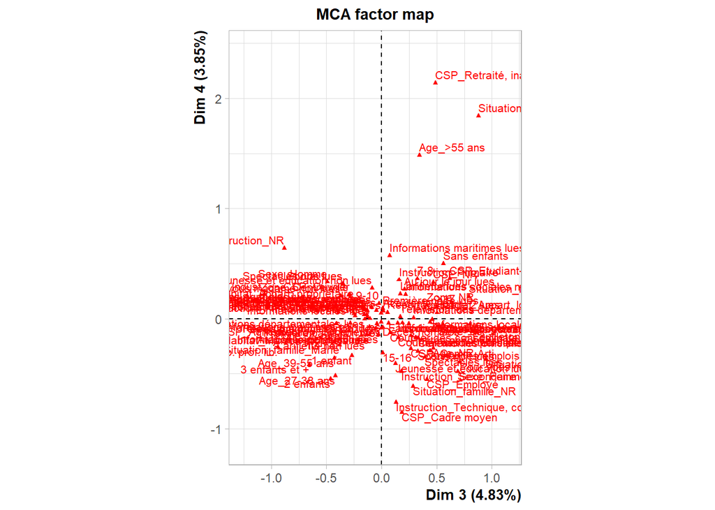

```r
plot(donnee1_mca, invisible=c("ind","quali.sup"),cex=0.7, axes=3:4)
```

```r
# Qualité de la représentation sur les 3 premiers axes
sort(donnee1_mca$var$cos2[,1], decreasing=TRUE)[1:5]
```

```
##            Décès lues        Décès non lues        Accidents lues
##             0.5466671             0.5466671             0.4334183
##    Accidents non lues Instruction_Supérieur
##             0.4334183             0.3286146
```

```r
sort(donnee1_mca$var$cos2[,2], decreasing=TRUE)[1:5]
```

```
##      Informations étrangères lues Informations  étrangères non lues
##                         0.4634286                         0.4634286
##     Informations économiques lues Informations économiques non lues
##                         0.4008077                         0.4008077
##      Informations politiques lues
##                         0.3959111
```

```r
sort(donnee1_mca$var$cos2[,3], decreasing=TRUE)[1:5]
```

```
##                Sexe_Homme                Sexe_Femme   Situation_famille_Marié
##                 0.3362549                 0.3223861                 0.3000308
##              Sans enfants Pour vous madame non lues
##                 0.2757183                 0.2628048
```

```r
# Contribution
sort(donnee1_mca$var$contrib[,1], decreasing=TRUE)[1:5]
```

```
##                Décès non lues            Accidents non lues
##                      5.393560                      4.695455
##         Instruction_Supérieur                 Age_18-26 ans
##                      4.195784                      3.789392
## Situation_famille_Célibataire
##                      3.621935
```

```r
sort(donnee1_mca$var$contrib[,2], decreasing=TRUE)[1:5]
```

```
## Informations  étrangères non lues  Informations politiques non lues
##                          5.349225                          5.318629
##      Informations étrangères lues     Informations économiques lues
##                          4.926122                          4.521858
## Informations économiques non lues
##                          4.365031
```

```r
sort(donnee1_mca$var$contrib[,3], decreasing=TRUE)[1:5]
```

```
##                    Sexe_Femme         Pour vous madame lues
##                      5.949619                      5.327887
##                  Sans enfants Situation_famille_Célibataire
##                      4.536918                      4.362742
##                 Age_18-26 ans
##                      4.349335
```

```r
# Description automatique
dimdesc(donnee1_mca)[[1]]$category
```

```
##                                                                        Estimate
## Décès=Décès non lues                                                0.314551073
## Accidents=Accidents non lues                                        0.289410882
## Instruction=Instruction_Supérieur                                   0.396809487
## Age=Age_18-26 ans                                                   0.404873082
## Courrier_des_consommateurs=Courrier des consommateurs non lues      0.232781791
## Situation_famille=Situation_famille_Célibataire                     0.286505317
## Courrier_des_lecteurs=Courrier des lecteurs non lues                0.227679062
## Au_jour_le_jour=Au jour le jour non lues                            0.224108424
## Informations_locales=Informations locales non lues                  0.262494102
## Cérémonies_officielles=Cérémonies officielles non lues              0.208669559
## Faits_divers=Faits divers non lues                                  0.209165160
## Pour_vous_madame=Pour vous madame non lues                          0.175002228
## Informations_départementales=Informations départementales non lues  0.173635818
## Habitat=Habitat_Appart. locataire                                   0.153539282
## Télévision=Télévision non lues                                      0.164830352
## Zone=Zone_Z. résidentielle                                          0.361798625
## Informations_agricoles=Informations agricoles non lues              0.175903276
## Nombre_rubriques_lues_QL=<6                                         0.377214055
## Petites_annonces=Petites annonces non lues                          0.141781737
## Feuilleton=Feuilleton non lues                                      0.187898957
## CSP=CSP_Etudiant-scolaire                                           0.768178772
## Spectacles=Spectacles lues                                          0.123001485
## CSP=CSP_Cad. sup. prof. lib.                                        0.313759387
## Lariflette=Lariflette non lues                                      0.111911994
## Nombre_rubriques_lues_QL=7-8                                        0.270480762
## Nb_enfants=Sans enfants                                             0.149997045
## Sexe=Sexe_Homme                                                     0.180124264
## Informations_étrangères=Informations étrangères lues                0.080651764
## CSP=CSP_NR                                                          0.121094272
## Nombre_rubriques_lues_QL=11-12                                      0.150587004
## Annonces_emplois=Annonces emplois non lues                          0.076625153
## Informations_politiques=Informations politiques lues                0.063152773
## Sports=Sports lues                                                  0.059121815
## Reportage_page_2=Reportage page 2 non lues                          0.056394843
## Habitat=Habitat_NR                                                  0.290930482
## Nombre_rubriques_lues_QL=9-10                                       0.115625543
## Informations_sociales=Informations sociales non lues                0.049869354
## Instruction=Instruction_Secondaire                                  0.062079393
## Zone=Zone_NR                                                       -0.230743557
```

[output cut: 101 more lines]

```
## Télévision=Télévision lues                                         8.488440e-12
## Age=Age_>55 ans                                                    3.297044e-12
## Informations_départementales=Informations départementales lues     2.615958e-14
## Pour_vous_madame=Pour vous madame lues                             2.037235e-14
## Situation_famille=Situation_famille_Marié                          3.667406e-15
## Faits_divers=Faits divers lues                                     9.354441e-18
## Cérémonies_officielles=Cérémonies officielles lues                 7.645431e-20
## Informations_locales=Informations locales lues                     3.699483e-22
## Nombre_rubriques_lues_QL=>17                                       6.009737e-23
## Instruction=Instruction_Primaire                                   5.898617e-23
## Au_jour_le_jour=Au jour le jour lues                               2.629342e-24
## Courrier_des_lecteurs=Courrier des lecteurs lues                   6.108538e-26
## Courrier_des_consommateurs=Courrier des consommateurs lues         3.682720e-27
## Accidents=Accidents lues                                           1.313482e-43
## Décès=Décès lues                                                   5.032233e-60
```

```r
dimdesc(donnee1_mca)[[2]]$category
```

```
##                                                                        Estimate
## Informations_étrangères=Informations étrangères lues                0.244578916
## Informations_économiques=Informations économiques lues              0.227297565
## Informations_politiques=Informations politiques lues                0.231111146
## Reportage_page_2=Reportage page 2 lues                              0.211881822
## Informations_sociales=Informations sociales lues                    0.203314296
## Première_page=Première page lues                                    0.175173747
## Nombre_rubriques_lues_QL=>17                                        0.421868431
## Jeunesse_et_éducation=Jeunesse et éducation lues                    0.156897269
## Spectacles=Spectacles lues                                          0.137757268
## Instruction=Instruction_Supérieur                                   0.203429039
## Informations_départementales=Informations départementales lues      0.132849360
## Annonces_emplois=Annonces emplois lues                              0.137393730
## Petites_annonces=Petites annonces lues                              0.104919783
## Zone=Zone_NR                                                        0.319359467
## Courrier_des_lecteurs=Courrier des lecteurs lues                    0.094763882
## Zone=Zone_Z. résidentielle                                          0.138181213
## Courrier_des_consommateurs=Courrier des consommateurs lues          0.088229321
## Sexe=Sexe_Homme                                                     0.037259910
## Nb_enfants=Sans enfants                                             0.123383008
## Informations_maritimes=Informations maritimes lues                  0.183118030
## Situation_famille=Situation_famille_Célibataire                     0.217255975
## CSP=CSP_NR                                                          0.148117380
## Zone=Zone_Centre ville                                              0.036743122
## Sports=Sports lues                                                  0.069797157
## Habitat=Habitat_Appart. locataire                                   0.129673288
## Décès=Décès non lues                                                0.066737689
## Nombre_rubriques_lues_QL=15-16                                      0.177134713
## Cérémonies_officielles=Cérémonies officielles lues                  0.061299319
## Informations_locales=Informations locales lues                      0.071294589
## CSP=CSP_Cad. sup. prof. lib.                                        0.150591832
## Age=Age_NR                                                          0.278916134
## Au_jour_le_jour=Au jour le jour lues                                0.052950313
## Télévision=Télévision lues                                          0.047880493
## Age=Age_18-26 ans                                                   0.008271617
## Nombre_rubriques_lues_QL=11-12                                      0.113171614
## CSP=CSP_Etudiant-scolaire                                           0.263187944
## Pour_vous_madame=Pour vous madame non lues                          0.041549705
## Pour_vous_madame=Pour vous madame lues                             -0.041549705
## Instruction=Instruction_Primaire supérieur                         -0.119344951
```

[output cut: 93 more lines]

```
## Instruction=Instruction_Primaire                                   6.109132e-07
## Petites_annonces=Petites annonces non lues                         2.650796e-07
## Nombre_rubriques_lues_QL=7-8                                       6.022190e-08
## Zone=Zone_ZUP                                                      3.617070e-08
## Annonces_emplois=Annonces emplois non lues                         1.389913e-10
## Informations_départementales=Informations départementales non lues 2.045075e-11
## Spectacles=Spectacles non lues                                     2.451073e-13
## Nombre_rubriques_lues_QL=<6                                        1.243372e-16
## Jeunesse_et_éducation=Jeunesse et éducation non lues               1.029701e-16
## Première_page=Première page non lues                               1.114777e-21
## Informations_sociales=Informations sociales non lues               1.633651e-28
## Reportage_page_2=Reportage page 2 non lues                         9.364965e-33
## Informations_politiques=Informations politiques non lues           6.957858e-39
## Informations_économiques=Informations économiques non lues         1.747819e-39
## Informations_étrangères=Informations  étrangères non lues          1.287529e-47
```

```r
dimdesc(donnee1_mca)[[3]]$category
```

```
##                                                                       Estimate
## Sexe=Sexe_Femme                                                     0.13829021
## Nb_enfants=Sans enfants                                             0.23362428
## Pour_vous_madame=Pour vous madame lues                              0.16403568
## Situation_famille=Situation_famille_Célibataire                     0.08710157
## Age=Age_18-26 ans                                                   0.19683799
## Spectacles=Spectacles lues                                          0.11253275
## Habitat=Habitat_Appart. locataire                                   0.18196887
## Informations_agricoles=Informations agricoles non lues              0.12348129
## Sports=Sports non lues                                              0.10373610
## Feuilleton=Feuilleton lues                                          0.14503689
## Télévision=Télévision lues                                          0.08854023
## Annonces_emplois=Annonces emplois lues                              0.09053022
## Informations_politiques=Informations politiques non lues            0.07769618
## Informations_économiques=Informations économiques non lues          0.07555678
## Situation_famille=Situation_famille_Veuf                            0.11387451
## Cérémonies_officielles=Cérémonies officielles lues                  0.07466041
## CSP=CSP_NR                                                          0.15962573
## Zone=Zone_ZUP                                                       0.08452069
## Informations_locales=Informations locales non lues                  0.08536616
## Informations_départementales=Informations départementales non lues  0.06739482
## Zone=Zone_Z. résidentielle                                          0.11933253
## Nombre_rubriques_lues_QL=>17                                        0.14883927
## Petites_annonces=Petites annonces lues                              0.06014712
## Informations_sociales=Informations sociales non lues                0.05369238
## Age=Age_>55 ans                                                     0.05773103
## Lariflette=Lariflette lues                                          0.04848768
## Au_jour_le_jour=Au jour le jour lues                                0.04864014
## Informations_étrangères=Informations  étrangères non lues           0.04271882
## CSP=CSP_Retraité, inactif                                           0.16648148
## CSP=CSP_Employé                                                     0.14319785
## Nombre_rubriques_lues_QL=7-8                                        0.09655060
## Courrier_des_lecteurs=Courrier des lecteurs lues                    0.03652812
## Instruction=Instruction_Primaire                                    0.08643463
## Nb_enfants=1 enfant                                                -0.01888092
## Courrier_des_lecteurs=Courrier des lecteurs non lues               -0.03652812
## Instruction=Instruction_Primaire supérieur                         -0.03415308
## Instruction=Instruction_NR                                         -0.22920285
## Nombre_rubriques_lues_QL=11-12                                     -0.08842318
## Habitat=Habitat_Maison propriétaire                                -0.02619485
```

[output cut: 85 more lines]

```
## Informations_économiques=Informations économiques lues             3.521894e-06
## Informations_politiques=Informations politiques lues               3.124846e-06
## Age=Age_27-38 ans                                                  2.064754e-06
## Annonces_emplois=Annonces emplois non lues                         8.168162e-07
## Télévision=Télévision non lues                                     7.435651e-07
## Age=Age_39-55 ans                                                  4.964080e-08
## CSP=CSP_Cad. sup. prof. lib.                                       9.385885e-10
## Feuilleton=Feuilleton non lues                                     7.059643e-10
## Nb_enfants=3 enfants et +                                          1.096614e-10
## Sports=Sports lues                                                 1.054111e-10
## Informations_agricoles=Informations agricoles lues                 9.804921e-11
## Spectacles=Spectacles non lues                                     1.906004e-12
## Pour_vous_madame=Pour vous madame non lues                         3.509707e-24
## Situation_famille=Situation_famille_Marié                          5.175905e-28
## Sexe=Sexe_Homme                                                    6.159719e-32
```

Pour les individus, de la même manière, on visualize des variables sur les axes (Notons que cette fois ci le nombres de points est énorme)

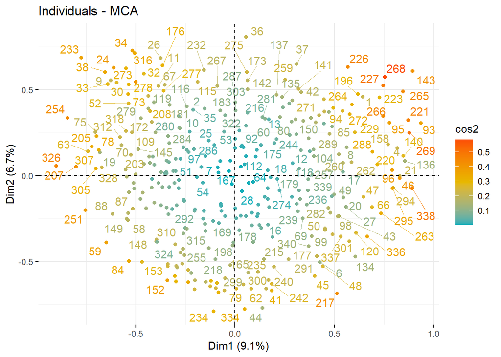

```r
fviz_mca_ind(donnee1_mca, col.ind = "cos2",
             gradient.cols = c("#00AFBB", "#E7B800", "#FC4E07"),
             repel = TRUE, # Avoid text overlapping (slow if many points)
             ggtheme = theme_minimal())
```

Ensuite, on visualize aussi un diagramme à barres de la contribution des individus

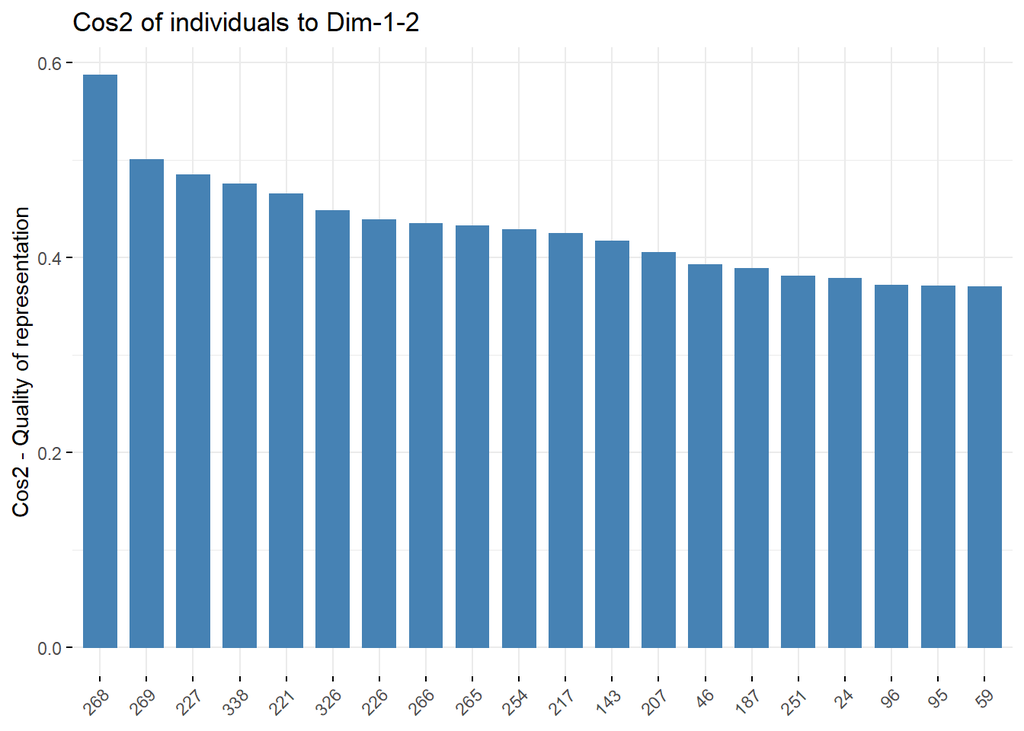

```r
fviz_cos2(donnee1_mca, choice = "ind", axes = 1:2, top = 20)
```

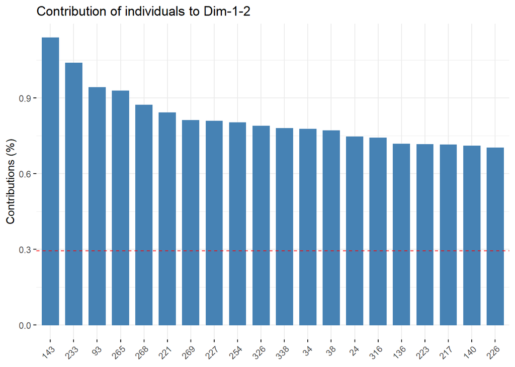

```r
fviz_contrib(donnee1_mca, choice = "ind", axes = 1:2, top = 20)
```

De plus, nous pouvons envisager les relations entre les individus et les variable en représentant :

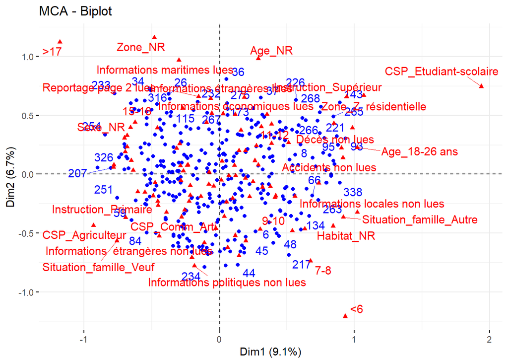

```r
fviz_mca_biplot(donnee1_mca, repel = TRUE,ggtheme=theme_minimal())
```

Dans une enquête réelle, on est intéressé par l’origine des individus, on peut grouper les individus par Zone.

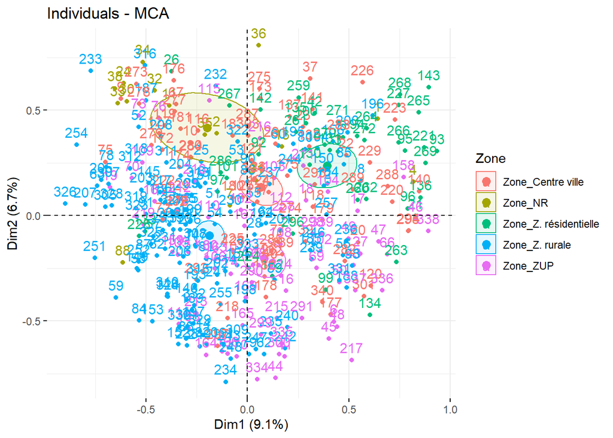

```r
fviz_mca_ind(donnee1_mca, habillage = "Zone",
             addEllipses = TRUE, ellipse.type = "confidence",
             ggtheme = theme_minimal())
```

Pour aller plus loin, on groupe les individus pas chque des 8 premiers variables

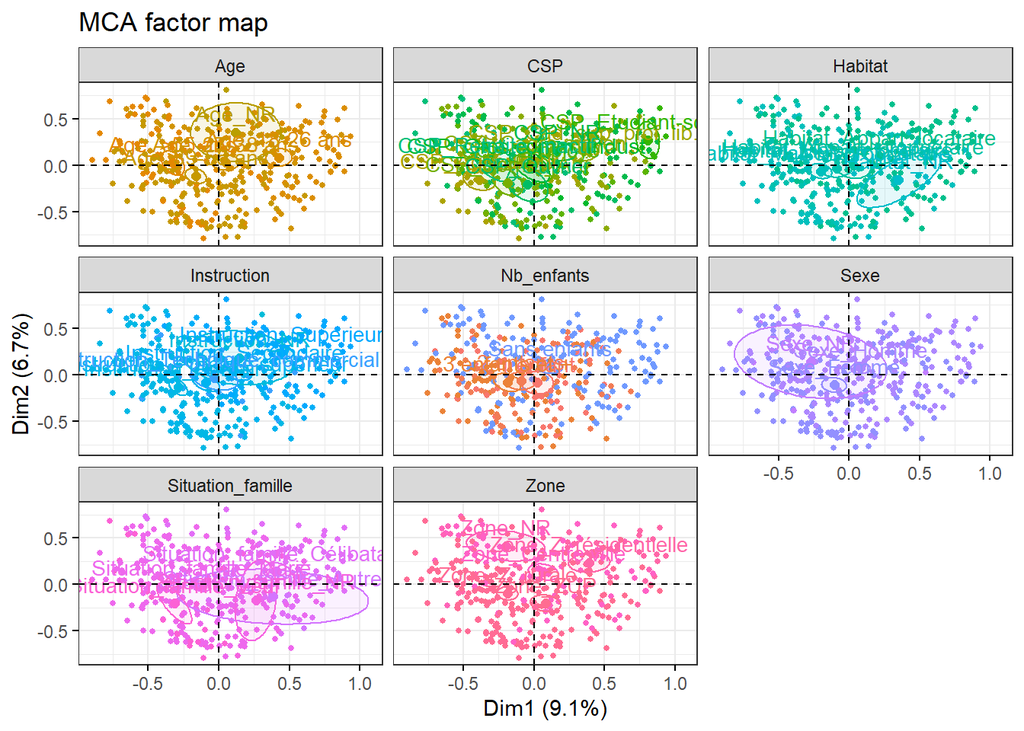

```r
fviz_ellipses(donnee1_mca, 2:9, geom = "point")
```

## Donnée2

Comme d’habitude, on va lire des données tout d’abord.

```r
#lire le tableau
donnee2 = read.csv2("wine.csv",header = TRUE)

row.names(donnee2)=donnee2$X
#nommer les indices

#séparer la colonne qualitative
rest=donnee2[2]

donnee2=apply(donnee2[,-c(1,2)],2,as.numeric)
#on change le type de variable

donnee2=cbind(rest,donnee2)
donnee2[,1]=as.factor(donnee2[,1])

summary(donnee2)
```

```
##        Label   Odor.Intensity.before.shaking Odor.Intensity.after.shaking
##  Sauvignon:5   Min.   :3.857                 Min.   :4.250
##  Vouvray  :5   1st Qu.:6.062                 1st Qu.:6.562
##                Median :6.938                 Median :7.312
##                Mean   :6.523                 Mean   :6.950
##                3rd Qu.:7.125                 3rd Qu.:7.594
##                Max.   :7.750                 Max.   :8.000
##    Expression       O.fruity       O.passion         O.citrus
##  Min.   :4.429   Min.   :2.143   Min.   :0.5000   Min.   :1.000
##  1st Qu.:6.000   1st Qu.:4.170   1st Qu.:0.7083   1st Qu.:2.857
##  Median :6.440   Median :4.339   Median :1.6429   Median :3.536
##  Mean   :6.274   Mean   :4.412   Mean   :1.8667   Mean   :3.662
##  3rd Qu.:6.929   3rd Qu.:5.143   3rd Qu.:2.9643   3rd Qu.:4.896
##  Max.   :7.143   Max.   :5.625   Max.   :4.0000   Max.   :5.714
##  O.candied.fruit    O.vanilla         O.wooded        O.mushroom
##  Min.   :0.6667   Min.   :0.5000   Min.   :0.3333   Min.   :0.2857
##  1st Qu.:1.1250   1st Qu.:0.5417   1st Qu.:0.3750   1st Qu.:0.3333
##  Median :2.9286   Median :0.9881   Median :0.9286   Median :0.8929
##  Mean   :2.5810   Mean   :1.9762   Mean   :2.1357   Mean   :1.1238
##  3rd Qu.:3.5119   3rd Qu.:1.8333   3rd Qu.:1.7500   3rd Qu.:1.6667
##  Max.   :4.7143   Max.   :6.2857   Max.   :7.7500   Max.   :3.0000
##     O.plante        O.flower       O.alcohol        Typicity
##  Min.   :1.857   Min.   :2.833   Min.   :1.667   Min.   :0.625
##  1st Qu.:3.167   1st Qu.:3.393   1st Qu.:2.658   1st Qu.:2.393
##  Median :4.330   Median :3.929   Median :3.238   Median :4.009
##  Mean   :4.217   Mean   :4.487   Mean   :3.095   Mean   :3.913
##  3rd Qu.:4.612   3rd Qu.:5.598   3rd Qu.:3.400   3rd Qu.:5.844
##  Max.   :6.500   Max.   :6.571   Max.   :4.286   Max.   :6.833
##  Attack.intensity   Sweetness        Acidity        Bitterness
##  Min.   :5.143    Min.   :3.000   Min.   :4.375   Min.   :2.500
##  1st Qu.:5.464    1st Qu.:3.308   1st Qu.:5.438   1st Qu.:3.812
##  Median :5.786    Median :3.500   Median :5.795   Median :4.062
##  Mean   :5.843    Mean   :3.904   Mean   :5.796   Mean   :3.975
##  3rd Qu.:6.357    3rd Qu.:3.844   3rd Qu.:6.312   3rd Qu.:4.219
##  Max.   :6.571    Max.   :7.875   Max.   :6.750   Max.   :5.000
##   Astringency      Freshness       Oxidation        Smoothness
##  Min.   :1.429   Min.   :4.286   Min.   :0.2857   Min.   :4.143
##  1st Qu.:2.375   1st Qu.:4.976   1st Qu.:0.4286   1st Qu.:4.268
##  Median :2.750   Median :5.792   Median :1.0833   Median :5.214
##  Mean   :2.851   Mean   :5.733   Mean   :1.3929   Mean   :4.988
##  3rd Qu.:3.125   3rd Qu.:6.576   3rd Qu.:1.7679   3rd Qu.:5.500
##  Max.   :4.250   Max.   :6.875   Max.   :4.0000   Max.   :6.000
##  Aroma.intensity Aroma.persistency Visual.intensity     Grade
##  Min.   :4.857   Min.   :5.143     Min.   :3.000    Min.   :2.429
##  1st Qu.:6.143   1st Qu.:5.714     1st Qu.:3.719    1st Qu.:3.857
##  Median :6.500   Median :6.238     Median :4.562    Median :4.143
##  Mean   :6.460   Mean   :6.100     Mean   :4.912    Mean   :4.926
##  3rd Qu.:7.107   3rd Qu.:6.571     3rd Qu.:6.188    3rd Qu.:6.679
##  Max.   :7.286   Max.   :6.714     Max.   :7.375    Max.   :7.429
##  Surface.feeling Odor.preferene  Overall.preference
##  Min.   :2.500   Min.   :4.400   Min.   :4.125
##  1st Qu.:2.975   1st Qu.:5.000   1st Qu.:5.000
##  Median :3.650   Median :5.214   Median :5.312
##  Mean   :3.623   Mean   :5.277   Mean   :5.252
##  3rd Qu.:4.108   3rd Qu.:5.850   3rd Qu.:5.500
##  Max.   :4.750   Max.   :6.143   Max.   :6.429
```

```r
#on fait un summary afin de vérifier les datas
```

[figure not shown]

```r
pairs(donnee2[,-1])
```

```r
round(cor(donnee2[,-1]),2)
```

```
##                               Odor.Intensity.before.shaking
## Odor.Intensity.before.shaking                          1.00
## Odor.Intensity.after.shaking                           0.98
## Expression                                             0.87
## O.fruity                                              -0.16
## O.passion                                              0.20
## O.citrus                                               0.14
## O.candied.fruit                                       -0.17
## O.vanilla                                              0.36
## O.wooded                                               0.37
## O.mushroom                                            -0.10
## O.plante                                               0.00
## O.flower                                               0.18
## O.alcohol                                              0.22
## Typicity                                              -0.39
## Attack.intensity                                       0.81
## Sweetness                                             -0.79
## Acidity                                                0.60
## Bitterness                                             0.62
## Astringency                                            0.12
## Freshness                                              0.26
## Oxidation                                             -0.18
## Smoothness                                            -0.16
## Aroma.intensity                                        0.61
## Aroma.persistency                                      0.75
## Visual.intensity                                       0.26
## Grade                                                  0.18
## Surface.feeling                                       -0.16
## Odor.preferene                                         0.21
## Overall.preference                                    -0.10
##                               Odor.Intensity.after.shaking Expression O.fruity
## Odor.Intensity.before.shaking                         0.98       0.87    -0.16
## Odor.Intensity.after.shaking                          1.00       0.87    -0.10
## Expression                                            0.87       1.00     0.28
## O.fruity                                             -0.10       0.28     1.00
## O.passion                                             0.21       0.46     0.42
## O.citrus                                              0.16       0.52     0.51
## O.candied.fruit                                      -0.15      -0.29     0.05
## O.vanilla                                             0.29       0.03    -0.56
## O.wooded                                              0.29       0.01    -0.66
```

[output cut: 215 more lines]

```
## Attack.intensity                        0.22              -0.05
## Sweetness                              -0.11               0.16
## Acidity                                 0.26              -0.39
## Bitterness                              0.28              -0.14
## Astringency                             0.07              -0.09
## Freshness                               0.53              -0.25
## Oxidation                              -0.70               0.46
## Smoothness                              0.73               0.21
## Aroma.intensity                         0.12               0.46
## Aroma.persistency                      -0.05               0.08
## Visual.intensity                       -0.36               0.21
## Grade                                  -0.35               0.13
## Surface.feeling                        -0.27               0.14
## Odor.preferene                          1.00              -0.27
## Overall.preference                     -0.27               1.00
```

Suite, on va effectuer un ACP

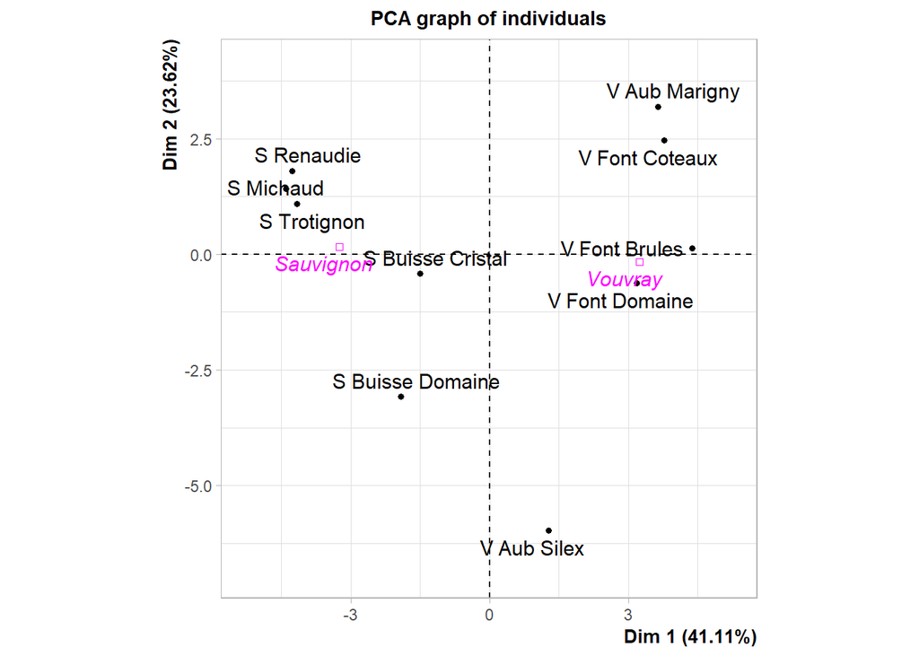

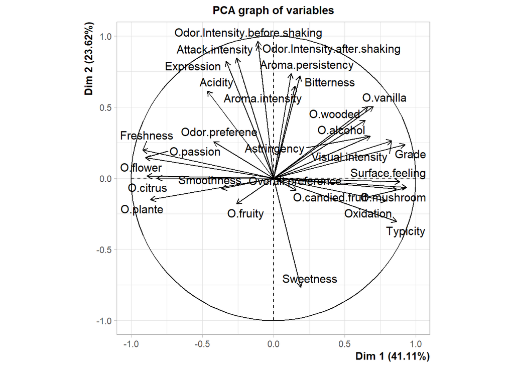

```r
library(FactoMineR)
# Réalisation de l'ACP
acp.wine<-PCA(donnee2, scale.unit=TRUE,quali.sup = 1)
```

```r
summary(acp.wine)
```

```
##
## Call:
## PCA(X = donnee2, scale.unit = TRUE, quali.sup = 1)
##
##
## Eigenvalues
##                        Dim.1   Dim.2   Dim.3   Dim.4   Dim.5   Dim.6   Dim.7
## Variance              11.921   6.849   3.427   2.218   2.011   1.034   0.821
## % of var.             41.108  23.618  11.817   7.649   6.933   3.566   2.831
## Cumulative % of var.  41.108  64.726  76.542  84.191  91.125  94.691  97.522
##                        Dim.8   Dim.9
## Variance               0.395   0.324
## % of var.              1.362   1.116
## Cumulative % of var.  98.884 100.000
##
## Individuals
##                                   Dist    Dim.1    ctr   cos2    Dim.2    ctr
## S Michaud                     |  5.556 | -4.402 16.254  0.628 |  1.421  2.949
## S Renaudie                    |  5.024 | -4.263 15.243  0.720 |  1.800  4.728
## S Trotignon                   |  4.852 | -4.165 14.549  0.737 |  1.093  1.745
## S Buisse Domaine              |  4.838 | -1.919  3.090  0.157 | -3.081 13.863
## S Buisse Cristal              |  4.095 | -1.496  1.877  0.133 | -0.419  0.256
## V Aub Silex                   |  6.595 |  1.270  1.352  0.037 | -5.977 52.164
## V Aub Marigny                 |  6.251 |  3.646 11.153  0.340 |  3.191 14.863
## V Font Domaine                |  4.427 |  3.181  8.487  0.516 | -0.624  0.569
## V Font Brules                 |  5.888 |  4.375 16.058  0.552 |  0.137  0.027
## V Font Coteaux                |  5.773 |  3.772 11.938  0.427 |  2.460  8.836
##                                 cos2    Dim.3    ctr   cos2
## S Michaud                      0.065 |  0.975  2.776  0.031 |
## S Renaudie                     0.128 |  0.835  2.036  0.028 |
## S Trotignon                    0.051 |  0.540  0.850  0.012 |
## S Buisse Domaine               0.406 | -1.620  7.658  0.112 |
## S Buisse Cristal               0.010 | -1.209  4.263  0.087 |
## V Aub Silex                    0.821 | -0.744  1.615  0.013 |
## V Aub Marigny                  0.261 | -2.940 25.218  0.221 |
## V Font Domaine                 0.020 |  1.837  9.845  0.172 |
## V Font Brules                  0.001 |  3.709 40.147  0.397 |
## V Font Coteaux                 0.182 | -1.384  5.591  0.057 |
##
## Variables (the 10 first)
```

[output cut: 15 more lines]

```
## O.fruity                       0.613 10.962  0.376 |
## O.passion                     -0.009  0.003  0.000 |
## O.citrus                       0.490  7.018  0.241 |
## O.candied.fruit                0.170  0.847  0.029 |
## O.vanilla                     -0.448  5.859  0.201 |
## O.wooded                      -0.503  7.373  0.253 |
## O.mushroom                     0.407  4.824  0.165 |
##
## Supplementary categories
##                                   Dist    Dim.1   cos2 v.test    Dim.2   cos2
## Sauvignon                     |  3.280 | -3.249  0.981 -2.823 |  0.163  0.002
## Vouvray                       |  3.280 |  3.249  0.981  2.823 | -0.163  0.002
##                               v.test    Dim.3   cos2 v.test
## Sauvignon                      0.187 | -0.096  0.001 -0.155 |
## Vouvray                       -0.187 |  0.096  0.001  0.155 |
```

les boîtes à moustaches des distributions

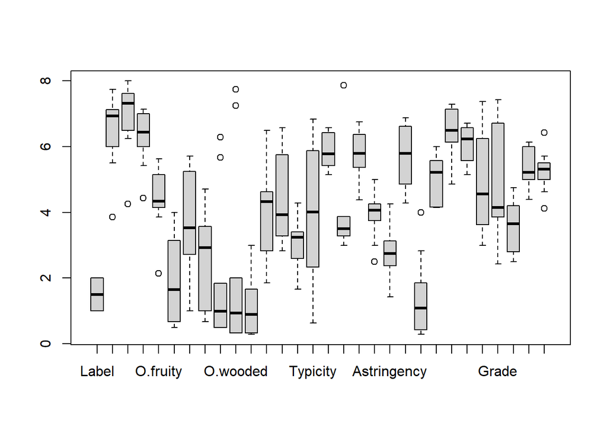

```r
boxplot(donnee2, names=colnames(donnee2))
```

```r
summary(acp.wine)
```

```
##
## Call:
## PCA(X = donnee2, scale.unit = TRUE, quali.sup = 1)
##
##
## Eigenvalues
##                        Dim.1   Dim.2   Dim.3   Dim.4   Dim.5   Dim.6   Dim.7
## Variance              11.921   6.849   3.427   2.218   2.011   1.034   0.821
## % of var.             41.108  23.618  11.817   7.649   6.933   3.566   2.831
## Cumulative % of var.  41.108  64.726  76.542  84.191  91.125  94.691  97.522
##                        Dim.8   Dim.9
## Variance               0.395   0.324
## % of var.              1.362   1.116
## Cumulative % of var.  98.884 100.000
##
## Individuals
##                                   Dist    Dim.1    ctr   cos2    Dim.2    ctr
## S Michaud                     |  5.556 | -4.402 16.254  0.628 |  1.421  2.949
## S Renaudie                    |  5.024 | -4.263 15.243  0.720 |  1.800  4.728
## S Trotignon                   |  4.852 | -4.165 14.549  0.737 |  1.093  1.745
## S Buisse Domaine              |  4.838 | -1.919  3.090  0.157 | -3.081 13.863
## S Buisse Cristal              |  4.095 | -1.496  1.877  0.133 | -0.419  0.256
## V Aub Silex                   |  6.595 |  1.270  1.352  0.037 | -5.977 52.164
## V Aub Marigny                 |  6.251 |  3.646 11.153  0.340 |  3.191 14.863
## V Font Domaine                |  4.427 |  3.181  8.487  0.516 | -0.624  0.569
## V Font Brules                 |  5.888 |  4.375 16.058  0.552 |  0.137  0.027
## V Font Coteaux                |  5.773 |  3.772 11.938  0.427 |  2.460  8.836
##                                 cos2    Dim.3    ctr   cos2
## S Michaud                      0.065 |  0.975  2.776  0.031 |
## S Renaudie                     0.128 |  0.835  2.036  0.028 |
## S Trotignon                    0.051 |  0.540  0.850  0.012 |
## S Buisse Domaine               0.406 | -1.620  7.658  0.112 |
## S Buisse Cristal               0.010 | -1.209  4.263  0.087 |
## V Aub Silex                    0.821 | -0.744  1.615  0.013 |
## V Aub Marigny                  0.261 | -2.940 25.218  0.221 |
## V Font Domaine                 0.020 |  1.837  9.845  0.172 |
## V Font Brules                  0.001 |  3.709 40.147  0.397 |
## V Font Coteaux                 0.182 | -1.384  5.591  0.057 |
##
## Variables (the 10 first)
```

[output cut: 15 more lines]

```
## O.fruity                       0.613 10.962  0.376 |
## O.passion                     -0.009  0.003  0.000 |
## O.citrus                       0.490  7.018  0.241 |
## O.candied.fruit                0.170  0.847  0.029 |
## O.vanilla                     -0.448  5.859  0.201 |
## O.wooded                      -0.503  7.373  0.253 |
## O.mushroom                     0.407  4.824  0.165 |
##
## Supplementary categories
##                                   Dist    Dim.1   cos2 v.test    Dim.2   cos2
## Sauvignon                     |  3.280 | -3.249  0.981 -2.823 |  0.163  0.002
## Vouvray                       |  3.280 |  3.249  0.981  2.823 | -0.163  0.002
##                               v.test    Dim.3   cos2 v.test
## Sauvignon                      0.187 | -0.096  0.001 -0.155 |
## Vouvray                       -0.187 |  0.096  0.001  0.155 |
```

On trace l’éboulis des valeurs propres et détermine le nombre d’axes à conserver pour effectuer l’analyse

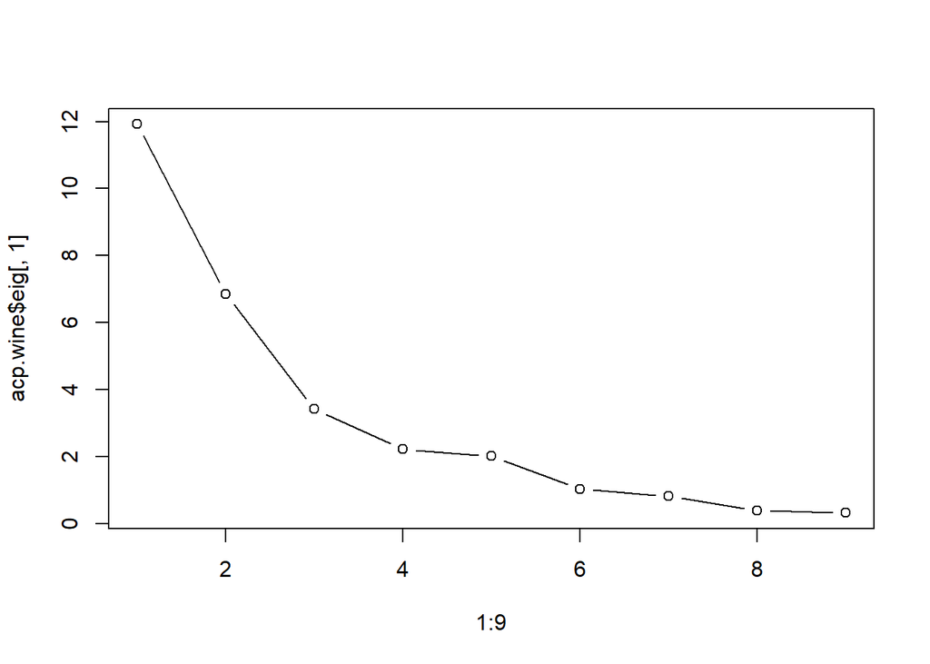

```r
# Eboulis des valeurs propres
plot(1:9, acp.wine$eig[,1], type="b")
```

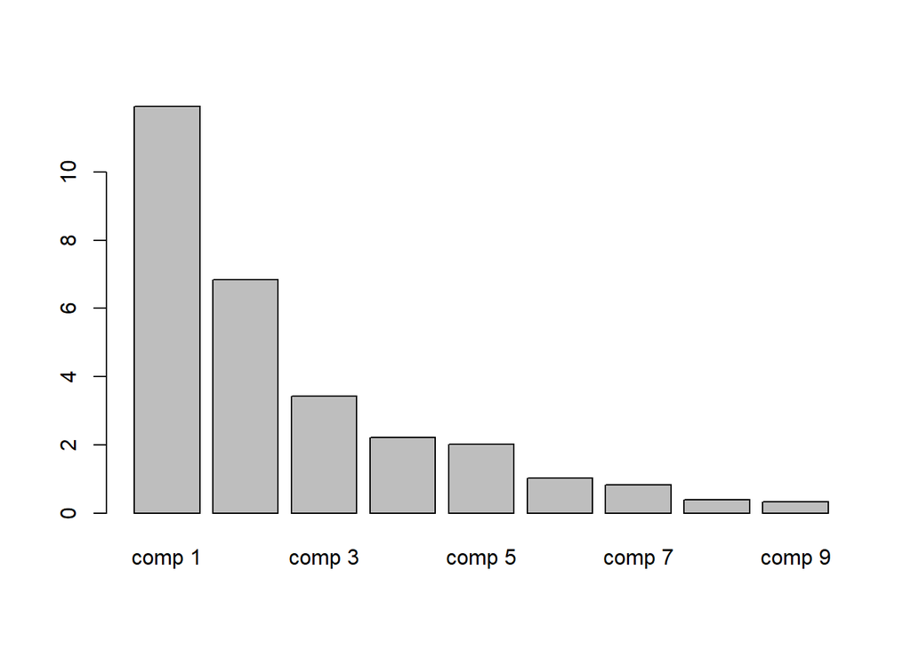

```r
barplot(acp.wine$eig[,1])
```

```r
sum(acp.wine$eig[,1]>1)
```

```
## [1] 6
```

On va conserver $6$ axes